[figure not shown]

# Protein Signal Intensities within Groups

Author

The CompMS team

Published

October 23, 2026

**Overview**

Samples**12**

Groups**3**

Proteins**100**

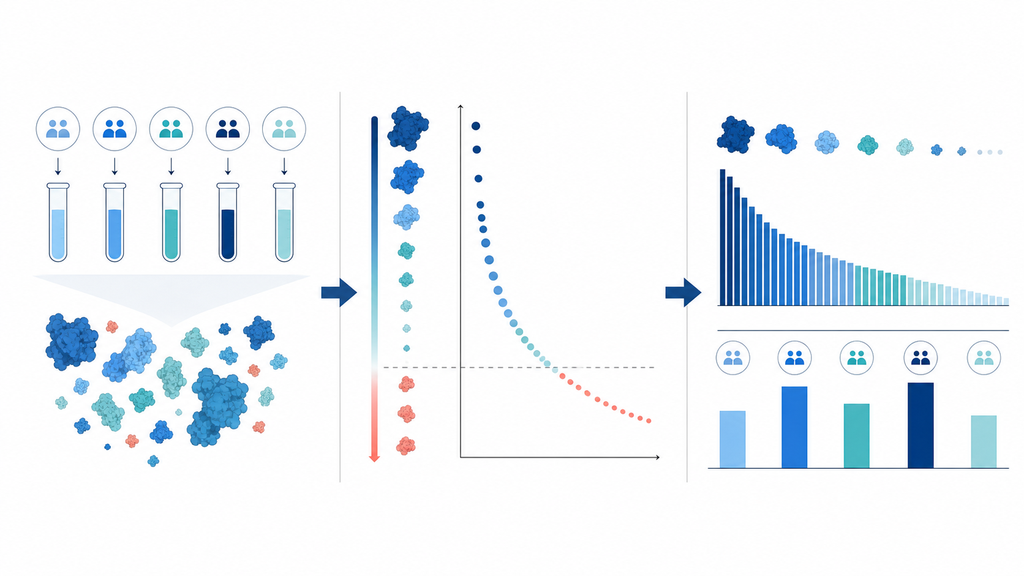

This report profiles how quantified protein signal is distributed across sample groups. It identifies dominant proteins and potential contaminants, then compares the number of quantified proteins per sample.

**Protein abundances**

[interactive chart not shown]

Figure 1: Per-protein iBAQ signal contribution versus abundance rank, one panel per group. Each point is one protein; the x-axis is the protein’s abundance-rank percentile (proteins ordered from lowest to highest mean iBAQ abundance) and the y-axis (log10 scale) is the percentage of the total iBAQ (intensity-based absolute quantification) signal contributed by that protein. Contaminant and decoy proteins are highlighted in red.

|  | protein_Id | nrPeptides | description | nrMeasured_All | nrMeasured_A | nrMeasured_B | nrMeasured_Ctrl | meanAbundance_All | meanAbundance_A | meanAbundance_B | meanAbundance_Ctrl | abundance_percent_All | abundance_percent_A | abundance_percent_B | abundance_percent_Ctrl |
| --- | --- | --- | --- | --- | --- | --- | --- | --- | --- | --- | --- | --- | --- | --- | --- |
| 1 | 0EfVhX~3967 | 2 | aH9xtgn1TlDJE | 12 | 4 | 4 | 4 | 11.5173387320975 | 11.8988802729644 | 13.57053894894669 | 9.082596974381412 | 1.2 | 1.2 | 1.3 | 0.96 |
| 2 | 0m5WN4~6025 | 7 | 8PPM98ESGr2Rn | 12 | 4 | 4 | 4 | 9.477873958574122 | 9.477465881886637 | 9.85547983914781 | 9.10067615468792 | 0.97 | 0.98 | 0.98 | 0.96 |
| 3 | 0YSKpy~2865 | 2 | 7YC7ktNf5NHoR | 11 | 4 | 3 | 4 | 7.123586747443781 | 6.332450107559644 | 6.994368944681533 | 8.011636739399604 | 0.73 | 0.65 | 0.69 | 0.85 |
| 4 | 3QLHfm~8938 | 1 | oonRkdi0TDNbL | 10 | 4 | 3 | 3 | 11.20015646524689 | 12.67913724981466 | 9.432700674133615 | 10.99563787693648 | 1.1 | 1.3 | 0.93 | 1.2 |
| 5 | 3QYop0~7543 | 7 | 6FfPm6QztsA8e | 12 | 4 | 4 | 4 | 12.06039311045837 | 11.54769611906608 | 11.60631715731931 | 13.02716605498971 | 1.2 | 1.2 | 1.1 | 1.4 |
| 6 | 76k03k~7094 | 4 | LeJBm5SVbKUxT | 12 | 4 | 4 | 4 | 13.46148295495044 | 11.68365091793333 | 15.91235543444024 | 12.78844251247774 | 1.4 | 1.2 | 1.6 | 1.3 |
| 7 | 7cbcrd~7351 | 2 | tubP9vI3wi8Yx | 12 | 4 | 4 | 4 | 14.18866616036814 | 15.30863915283085 | 12.90574180891252 | 14.35161751936104 | 1.5 | 1.6 | 1.3 | 1.5 |
| 8 | 7QuTub~1867 | 4 | aPeJJDMz958gc | 12 | 4 | 4 | 4 | 9.106577215621435 | 7.542877463437241 | 11.5929901205693 | 8.183864062857761 | 0.93 | 0.78 | 1.1 | 0.86 |
| 9 | zz7soopj~5352 | 2 |  | 12 | 4 | 4 | 4 | 9.033364121570147 | 10.00319846699484 | 8.024785793772834 | 9.07210810394276 | 0.92 | 1 | 0.79 | 0.96 |
| 10 | 7zeekV~7127 | 8 | tfjWeomyRJP0B | 12 | 4 | 4 | 4 | 8.907537691726638 | 7.642179853932674 | 10.22442558235462 | 8.856007638892622 | 0.91 | 0.79 | 1 | 0.93 |

[output cut: 90 more lines]

**NoteTable columns**

**NoteWhat is the iBAQ signal?**

The iBAQ signal per protein is calculated by summing the `Precursor.Quantity` values across all precursors assigned to the protein and dividing by the number of theoretically observable peptides. A large share of the recorded signal can be concentrated in a small set of highly abundant proteins. If the dominant proteins are the cleavage enzyme, common contaminants such as human keratins, or the bait protein, this can indicate shortcomings in sample preparation or cleanup.

**Proteins per sample**

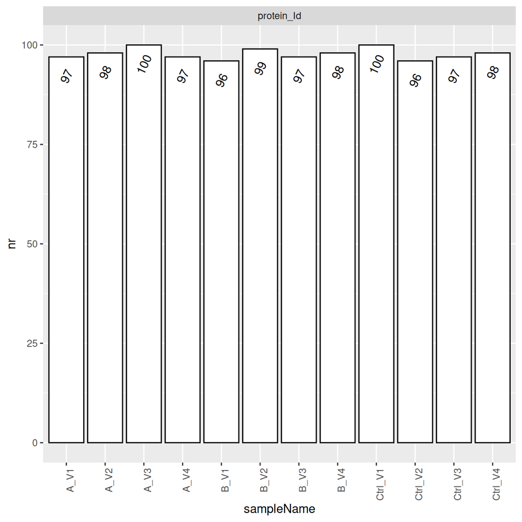

Figure 2: Number of proteins quantified per sample.

**Session Info**

**Report provenance**

Table 1: Compact report provenance, including the source input-data reference.

| Field | Value |
| --- | --- |
| Workunit ID | n/a |
| Order ID | n/a |
| Project ID | n/a |
| Project name | n/a |
| Creator | runner |
| Created at | 2026-10-23 05:11:00 UTC |
| Input data | n/a |
| Quantification software | n/a |
| Model | n/a |
| prolfquapp version | 2.11.0 |

**R session info**

[session information not shown]

## Download

- Qmd source
- HTML page

Select all plots

Plots download at the resolution embedded in the report (its fig-dpi). Interactive (plotly) charts aren't listed — export those from their own toolbar.